# Analyzing Study Habits A Comparative and Temporal Study of Personal and Class-Wide Data

Sparsh Shrestha

2024-07-03

## **Introduction**

### **Data Sets**

#### **Personalized Data Set**

I have collected personalized data about myself on how I spend my days during my 1st and 2nd semesters. I recorded data from January 14th, 2022, to April 13th, 2022, for my 1st semester and May 9th, 2022 to August 12th, 2022, for my 2nd semester on these variables:

| Variables | Type |
| --- | --- |
| **Date** | Identifier |
| Hours in Class | Quantitative |
| **Hours Studying** | Quantitative |
| Hours Sleeping | Quantitative |
| Number of Times Leaving the House | Quantitative |
| Watching the News | Categorical |
| Online Course Taken | Categorical |
| Day Satisfaction | Categorical |
| Work Hours | Quantitative |
| **Semester (1st or 2nd)** | Categorical |

Although 10 different variables are recorded in the data set, I will only use 3 variables from the data set. The first variable is Date which is used as an identifier for each row of data. The second variable that I will use for this analysis is a quantitative variable, Hours Studying. This variable is the sum of the hours I spent in classes, doing an assignment, and doing an online course. I am currently a student so most of my time in a day is spent studying. The last variable I will be using for this analysis is the categorical, Semester which groups the data between my first semester (Winter2022) and second semester (Spring2022).

#### **Combined Class Data Set**

The combined class data set is the collection of the data collected by past students in 3 different programs: BAPG, HAGC, and CAGC. This data set contains 4 variables shown in the table below.

| Variables | Type |
| --- | --- |
| Date | Identifier |
| Hours Studying | Quantitative |
| Term (F19, W20, F21 or W22) | Categorical |
| Program (BAPG, CAGC, HAGC) | Categorical |

The first variable in the combined class data set is the same as in the personalized data set, the date which is an identifier. The second variable is a quantitative variable, hours studying. It is the average number of hours all students spend studying on a certain date. The third variable is a categorical variable, semester which groups the data for a different semester. And the last variable is also categorical, the program that groups the 3 different programs for which the data is collected.

### **Summary Statistics**

The following table shows the mean and standard deviation for hours spent studying by me, all the previous students in all 3 programs and all the previous students in 3 different programs.

| Data Set | Mean | Standard Deviation |
| --- | --- | --- |
| Sparsh | 5.06 | 2.39 |
| All Students | 3.6 | 2.36 |
| BAPG | 3.54 | 2.37 |
| CAGC | 4.08 | 2.55 |
| HAGC | 3.81 | 2.13 |

The following tables show the other remaining summary statistics for hours spent studying by me, all the previous students in all 3 programs and all the previous students in 3 different programs.

```
## [1] "Sparsh"
```

```
##    Min. 1st Qu.  Median    Mean 3rd Qu.    Max.
##   0.000   4.000   5.000   5.065   6.750  12.000
```

```
## [1] "Combined"
```

```
##    Min. 1st Qu.  Median    Mean 3rd Qu.    Max.
##   0.000   2.000   3.000   3.601   5.000  20.000
```

```
## [1] "BAPG"
```

```
##    Min. 1st Qu.  Median    Mean 3rd Qu.    Max.
##   0.000   2.000   3.000   3.543   5.000  20.000
```

```
## [1] "CAGC"
```

```
##    Min. 1st Qu.  Median    Mean 3rd Qu.    Max.
##    0.00    2.50    4.00    4.08    5.00   15.00
```

```
## [1] "HAGC"
```

```
##    Min. 1st Qu.  Median    Mean 3rd Qu.    Max.
##   0.000   2.000   4.000   3.812   5.000   9.000
```

### **Purpose and Methods**

The purpose of this analysis is to answer 3 different questions. The first is to figure out if the average study time is different for students in different analytics streams. The second question that needs to be answered is if the distribution of days studied more than 3.13 hours same for students in different analytics programs, or in other words, are the distribution of the studied hours independent of the program stream or not? The third issue that needs to be addressed is identifying how my study time changes over time from the start of the 1st semester to the end of the 2nd semester. To answer these questions I mentioned above I will use 3 different methods: ANOVA Test, Chi-Square Test, and Time-Series Analysis.

ANOVA also known as Analysis of Variance will be used to figure out the difference in average study time in different streams as ANOVA is used to compare means of more than 2 groups. Tukey’s HSD test will also be used for the first question to determine which average is different in different analytics streams.

The Chi-Square test for Independence is used to figure out if two variables are independent of each other or not. And the Chi-Square test will be used to answer the second question in this analysis if the distribution of studied hours is independent of the program stream or not.

Finally, a time-series analysis will be done to identify how my study time changes over time. All the components of the time series will also be analyzed. 3 Different moving average models for studied hours will be plotted and the best will be identified. Moreover, the best exponential smoothing model for hours studied will also be identified and plotted.

## **Data Analysis**

### **ANOVA – comparing average study time for different program streams**

#### **Hypotheses**

Null Hypothesis $\rightarrow$ $H_0: \mu_B = \mu_C = \mu_H$

Alternative Hypothesis $\rightarrow$ $H_A:$ At least one mean is different

#### **ANOVA Test**

The following table shows the summary statistics for the ANOVA test

```
##              Df Sum Sq Mean Sq F value  Pr(>F)
## Program       2   73.0   36.50   6.858 0.00142 **
## Residuals   147  782.4    5.32
## ---
## Signif. codes:  0 '***' 0.001 '**' 0.01 '*' 0.05 '.' 0.1 ' ' 1
```

$P-value =$ 0.0014211 $< \alpha = 0.05$

The P-value of the ANOVA test is 0.0014211 which is less than the $\alpha$ (0.05), so we reject the null hypothesis. This means that there is enough evidence that there is at least one program where the average study hour is significantly different than other programs.

#### **Assumptions and Conditions**

The following assumptions and conditions must be met for the ANOVA test to be valid:

**1. Independence Assumption:** 50 random samples are taken from the combined data set for each program which are independent of each other. So, this condition is met.

**2. Similar Variance Assumption:** The box plot below shows that there is not any vast difference between the variance of the different programs. So, this assumption is also met.

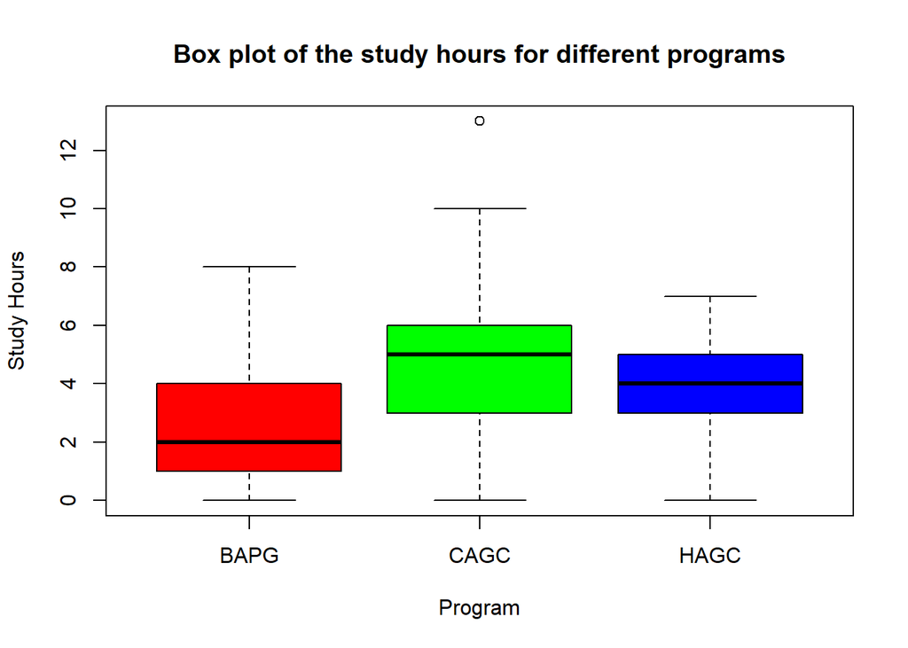

**3. Normal Population Assumption:** The histogram of residuals looks nearly normal which means that the normal population condition is also met.

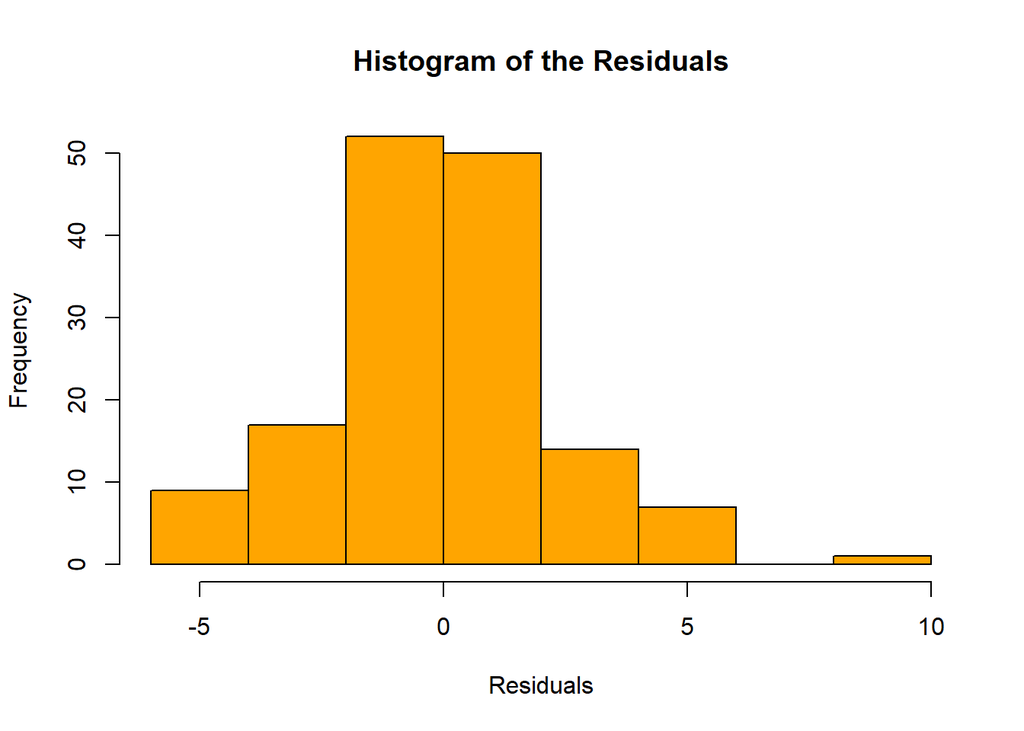

Since all the conditions are met the results of the ANOVA test are valid.

#### **Tukey’s HSD**

The following table shows the output for Tukey’s HSD test on the 50 samples for all the 3 programs.

```
##            diff        lwr       upr      p adj
## CAGC-BAPG  1.65  0.5574943 2.7425057 0.00136640
## HAGC-BAPG  1.21  0.1174943 2.3025057 0.02597714
## HAGC-CAGC -0.44 -1.5325057 0.6525057 0.60733718
```

From the above table, it can be seen that both (CAGC-BAPG) and (HAGC-BAPG) is less than the $\alpha$ (0.05) which means that we reject the null hypothesis in this case. In the case of (HAGC-CAGC), we fail to reject the null hypothesis as it is greater than the $\alpha$ (0.05). This analysis leads to the conclusion that the average study hours for BAPG are different from the other programs.

#### **Bar Plot of group means**

The following bar plot illustrates the average study hours for each program. It is clear from the box plot that the average study hours for BAPG are less than the average study hours for the CAGC and HAGC programs.

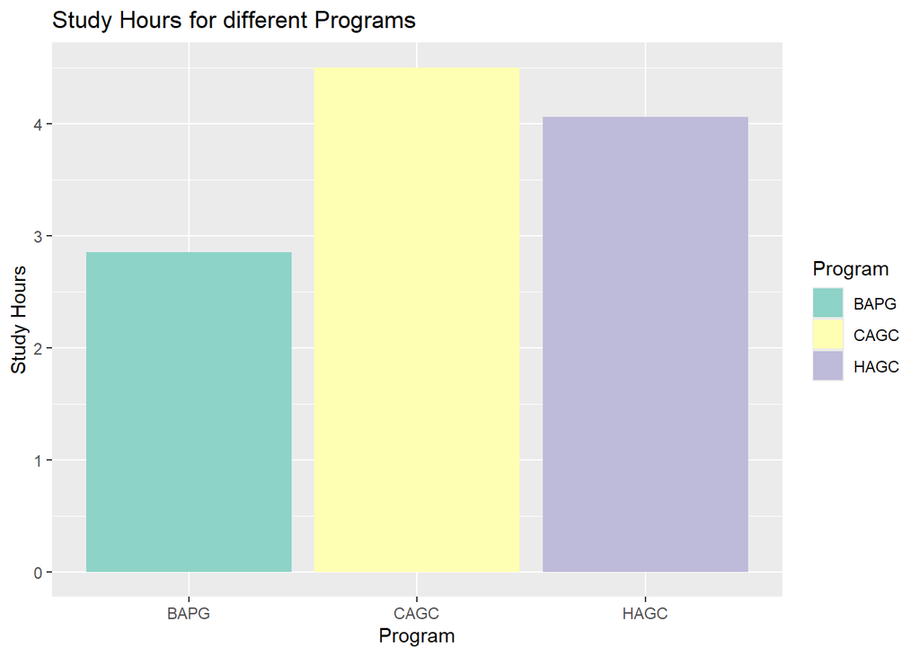

### **Chi-Square Tests – comparing the distribution of study time by program stream**

#### **Hypotheses**

Alternative Hypothesis $\rightarrow$ $H_A:$ The hours of study above or below the mean (3.13) are not independent of the program.

```
##
##         BAPG CAGC HAGC
##   Above   20   33   34
##   Below   30   17   16
```

#### **Chi-Square test for Independence**

The following figure shows the output for the Chi-Square test.

```
##
##  Pearson's Chi-squared test
##
## data:  observed.hours
## X-squared = 10.016, df = 2, p-value = 0.006683
```

$P-value =$ 0.0066829 $< \alpha = 0.05$

The P-value of the Chi-square test is less than the α (0.05) which means that we reject the null hypothesis. There is significant evidence that the hours of study above or below the mean are dependent on the program.

#### **Assumptions and Conditions**

**1. Counted Data Condition:** The data is counted for the categories (Above or Below) of a categorical variable. This condition is met.

**2. Independent Assumption:** The counts in the cells are independent of each other as the data for each variable was collected on a different day for different programs.

**3. Randomization Condition:** The random sample of 50 values is collected from all the 3 programs. So, this condition is also met.

All the conditions for the Chi-Square test are met. So, the test result is valid.

#### **Mosaic Plot**

The mosaic plot below represents the study hours above and below the mean (3.13) across all 3 programs. No box is coloured in the plot which means that all the residuals are between -2 and +2. The below category is more narrow compared to the above category which means that most of the students in all the programs study for more than 3.13 hours. HAGC has the highest bar in the above Column which means that HAGC has the highest number of students who study more than 3.13 hours and BAPG students have the lowest amount in the above category. On the other side, BAPG has the highest number of study hours below 3.13 hours and HAGC has the lowest study hours below 3.13 hours.

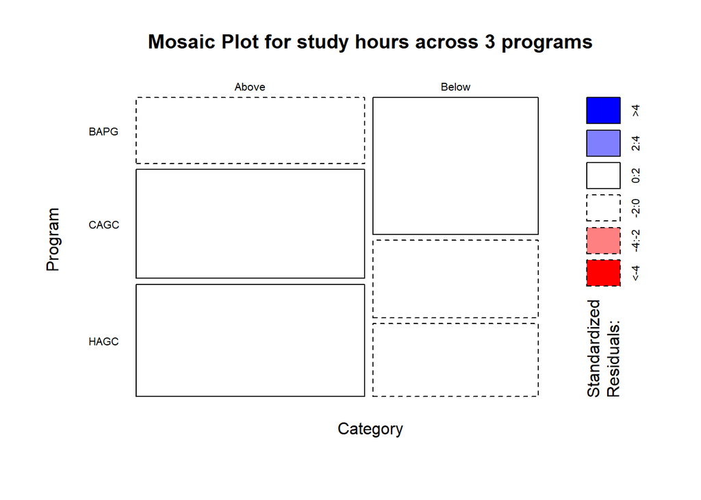

This analysis showed that the students studying above or below 3.13 hours have a relationship with which program they study in but I think that the main factor for the study hours are students themselves rather than the program they choose as the amount of workload and course content of all the 3 programs is same in the most part. As I am a BAPG student myself I know how heavy the workload for the BAPG program is and I think the reason for the BAPG having more study hours below the mean is the students in the program are not spending enough time on their studies whereas other program student giving more time in their studies.

### **Time Series Analysis – how does my study time change over time?**

#### **Decomposition of the time series**

**2. Seasonal component:** There is a seasonal component to the time series. The same pattern keeps repeating over time, in this case, it’s repeating weekly. The peak in the seasonal components should be during weekends when I study the most as I don’t have work and classes during this time. And the decline in the seasonal components should be during weekdays (Tuesday and Wednesday) when I had most of my classes and work shifts.

**3. Cyclical component:** There is no cyclical component in this time series because the duration of the data collected is less than a year. And we need data for years to correctly identify cyclical components in a time series.

**4. Irregular component:** There are irregular components in the time series. It is hard to figure out what each spike in the irregular components represents but its most likely some of the real-life disturbances in my study hours like I did not study for some days when I got sick once and once I had to shift my place of residence and could not study for few days.

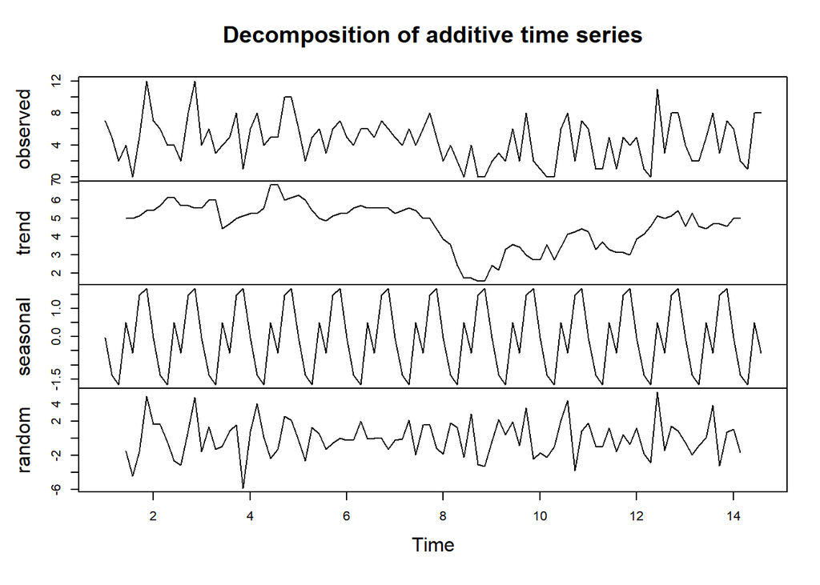

#### **Moving Average Models**

The plot below represents the time series graph for the hour studied by me from January 14, 2022, till August 12, 2022.

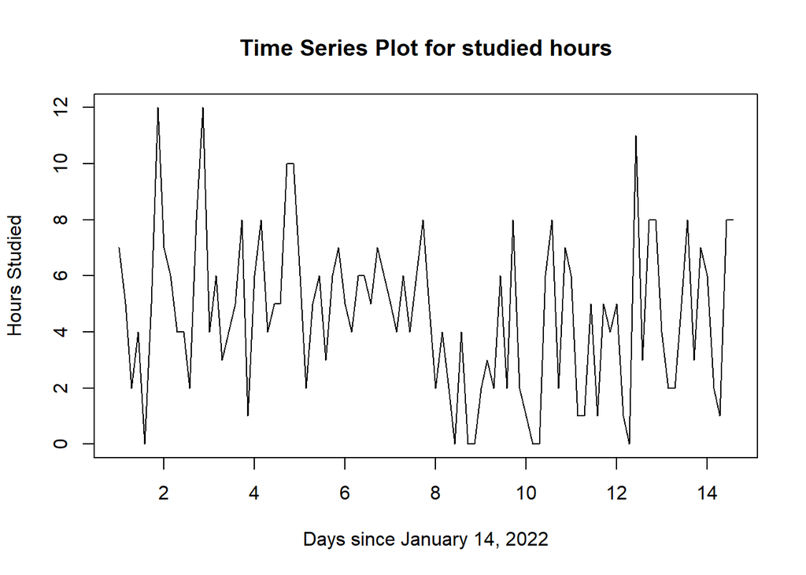

The following plot shows the graph for the original data and moving averages of lengths 5, 10, and 15. The black line represents the original time series data. The red line represents the moving average of length 5 and it seems the be following the trends in data more closely than other moving averages. Whereas the moving average with the length of 15 is represented by the blue line which seems smoother and follows the trend slower than other moving averages. The green line representing MA10 seems to be in between the other two moving averages in following the trend and smoothness of the line.

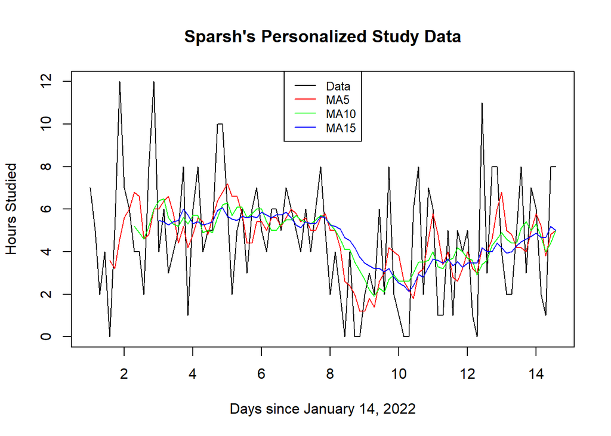

##### **Forecast**

The following table shows the forecast for the next day for moving averages. And all the models show the same value for the forecast of study hours on the next day which is 5 hours. Since my average study hours overall is 5.065 hours the predictions might not be far off in this case.

```
## [1] "MA5 = 5"
```

```
## [1] "MA10 = 5"
```

```
## [1] "MA15 = 5"
```

##### **Forecast Error**

```
##           MA5     MA10     MA15
## MSE  9.439121 7.673256 6.870837
## MAD  2.527473 2.197674 2.119342
## MAPE      Inf      Inf      Inf
```

#### **Exponential Smoothing**

##### **Choosing Best Exponential Smoothing Model**

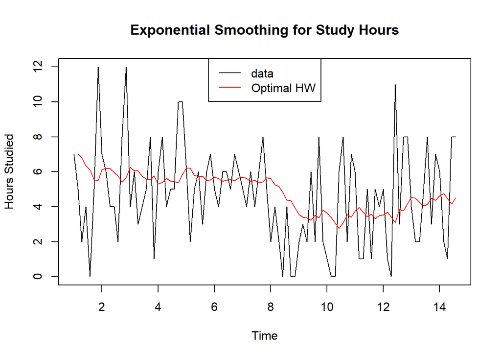

##### **Checking the accuracy of the Exponential Smoothing Model**

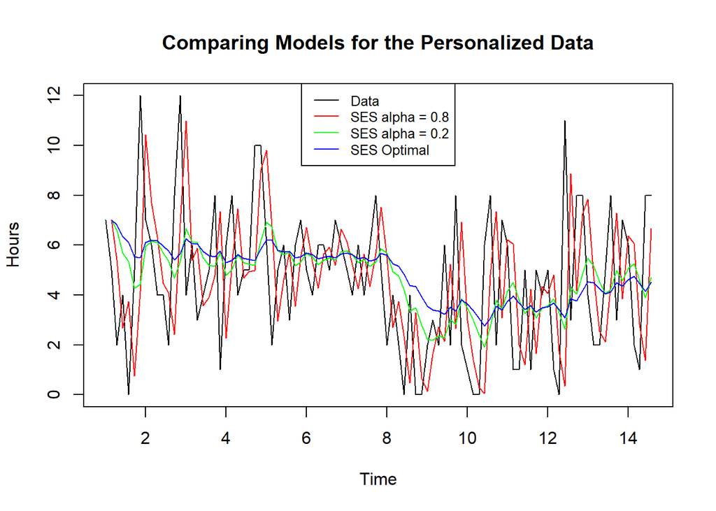

The following table shows the error metrics for the simple smoothing model when $\alpha$=0.8 and $\alpha$=0.2, the Optimal smoothing model and the moving average model. According to the table, the Optimal Smoothing Model is the best exponential model but the Moving Average Model seems to be more accurate compared to the exponential model. The reason for this may be because of a change in my work schedule in the last 2 months of the collected data which directly affects the study hours. The exponential model accounts for all the past data whereas Moving Average accounts for the data within the moving window size. So, the change in my work hours completely changed my study hours on different days resulting in the moving average being more accurate.

```
## [1] "SES0.80"
```

```
##                       ME     RMSE      MAE  MPE MAPE    MASE       ACF1
## Training set 0.009664722 3.348118 2.739962 -Inf  Inf 1.18377 -0.2618455
```

```
## [1] "SES0.20"
```

```
##                       ME     RMSE      MAE  MPE MAPE    MASE      ACF1
## Training set -0.08606776 2.875273 2.342638 -Inf  Inf 1.01211 0.0484023
```

```
## [1] "Optimal"
```

```
##                     ME     RMSE      MAE  MPE MAPE      MASE     ACF1
## Training set -0.236161 2.831448 2.313142 -Inf  Inf 0.9993671 0.105985
```

```
## [1] "Moving Average"
```

```
##                   ME     RMSE      MAE  MPE MAPE       ACF1 Theil's U
## Test set -0.07489712 2.621228 2.119342 -Inf  Inf 0.07104714         0
```

##### **Forecast using the Exponential Smoothing Model**

The following table shows the prediction for study hours for the next 5 days. The 5 columns represent the mean, lower 80% confidence interval, higher 80% confidence interval, lower 95% confidence interval, and higher 95% confidence interval for study hours.

```
##          Point Forecast    Lo 80    Hi 80      Lo 95    Hi 95
## 14.71429       4.848758 1.213572 8.483944 -0.7107798 10.40830
## 14.85714       4.848758 1.196898 8.500617 -0.7362791 10.43379
## 15.00000       4.848758 1.180301 8.517215 -0.7616626 10.45918
## 15.14286       4.848758 1.163779 8.533737 -0.7869317 10.48445
## 15.28571       4.848758 1.147330 8.550186 -0.8120880 10.50960
```

The following plot illustrates the forecasted values for the next 5 days. The blue straight line in the middle is the median mean value, the darker shade represents the 80% confidence interval and the light shade represents the 95% confidence interval.

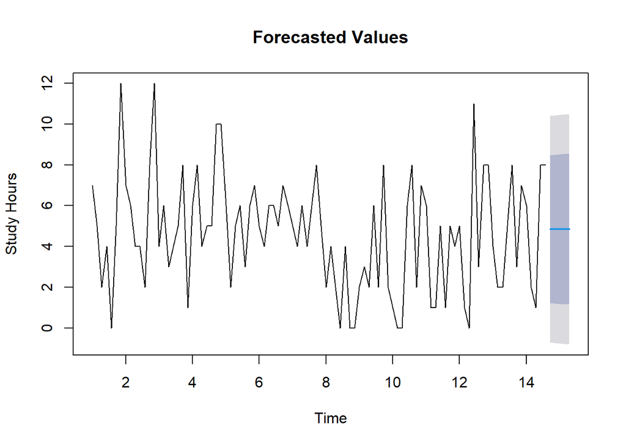

## **Conclusion**

To determine, if there is a difference in average study times for students in different analytics streams, the ANOVA test and Tukey’s HSD were performed. The ANOVA test indicated that there is at least one program where the average study hour is significantly different than other programs. Additionally, Tukey’s HSD showed that average study hours for BAPG are different from the other programs. Moreover, the bar plot unveiled that the average study hours for BAPG is less than the average study hours for the CAGC and HAGC programs.

To determine, if the distribution of days studied for more than 3.13 hours by students in the different programs independent of program stream Chi-Square Test for Independence was used. The Chi-Square test showed that there is significant evidence that the hours of study are dependent on the program. The analysis showed that the students studying more than 3.13 hours have a relationship with which program they studied. The mosaic plot showed that most of the students who combined in all the programs studied for more than 3.13 hours. But when we look at the specific programs most of the students in the BAPG program study less than 3.13 hours whereas most of the students in the CAGC and HAGC programs study more than 3.13 hours.